# hw3

## Building the Model

```python
months = [1,2,3,4,5,6,7,8,9,10,11,12]
months = 8*months
del months[-1]
df["months"] = months
```

```python
log_sales_data["trend"] = list(range(1, len(df)+1))
log_sales_data["month"] = months

sales_data["trend"] = list(range(1, len(df)+1))
sales_data["month"] = months
```

```python
lm = LinearRegression()
y = sales_data.sales
x = sales_data[["trend", "month"]]

model = OLS(y,x).fit()
model.summary()
```

OLS Regression Results

| Dep. Variable: | sales | R-squared (uncentered): | 0.893 |
| --- | --- | --- | --- |
| Model: | OLS | Adj. R-squared (uncentered): | 0.890 |
| Method: | Least Squares | F-statistic: | 386.2 |
| Date: | Wed, 13 Jan 2021 | Prob (F-statistic): | 9.03e-46 |
| Time: | 01:41:54 | Log-Likelihood: | -1082.2 |
| No. Observations: | 95 | AIC: | 2168. |
| Df Residuals: | 93 | BIC: | 2174. |
| Df Model: | 2 |  |  |
| Covariance Type: | nonrobust |  |  |

|  | coef | std err | t | P>\|t\| | [0.025 | 0.975] |
| --- | --- | --- | --- | --- | --- | --- |
| trend | 644.8876 | 65.529 | 9.841 | 0.000 | 514.760 | 775.015 |
| month | 4057.9797 | 496.555 | 8.172 | 0.000 | 3071.920 | 5044.040 |

| Omnibus: | 2.344 | Durbin-Watson: | 0.626 |
| --- | --- | --- | --- |
| Prob(Omnibus): | 0.310 | Jarque-Bera (JB): | 1.809 |
| Skew: | 0.170 | Prob(JB): | 0.405 |
| Kurtosis: | 3.584 | Cond. No. | 12.5 |

Warnings:  
[1] Standard Errors assume that the covariance matrix of the errors is correctly specified.

Before building a more complicated time-series model, I will check the residuals. After that I will build the model that contains interest rate parameter then compare it with this model in terms of R^2 and other statistical parameters. This way I can easyly conclude the effect of interest rate in second hand house sales in Turkey.

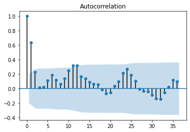

```python
plot_acf(model.resid, lags=36)
plt.show()
```

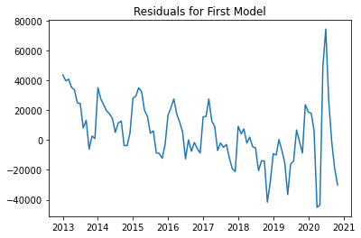

```python
fig, ax = plt.subplots()
ax.plot(log_sales_data.index, model.resid)
plt.title("Residuals for First Model")
plt.show()
```

#### Mean of the residuals is approximately 0 which is good.

#### The most important thing about residuals here is variance is not seem to be constant. So I will add a constant term to eliminate this problem.

```python
lm2=LinearRegression()
y_log = log_sales_data.sales
x_log = log_sales_data[["trend", "month"]]
model_log = OLS(y_log,x_log).fit()
model_log.summary()
```

OLS Regression Results

| Dep. Variable: | sales | R-squared (uncentered): | 0.866 |
| --- | --- | --- | --- |
| Model: | OLS | Adj. R-squared (uncentered): | 0.863 |
| Method: | Least Squares | F-statistic: | 300.5 |
| Date: | Wed, 13 Jan 2021 | Prob (F-statistic): | 2.58e-41 |
| Time: | 01:33:32 | Log-Likelihood: | -267.17 |
| No. Observations: | 95 | AIC: | 538.3 |
| Df Residuals: | 93 | BIC: | 543.5 |
| Df Model: | 2 |  |  |
| Covariance Type: | nonrobust |  |  |

|  | coef | std err | t | P>\|t\| | [0.025 | 0.975] |
| --- | --- | --- | --- | --- | --- | --- |
| trend | 0.0918 | 0.012 | 7.450 | 0.000 | 0.067 | 0.116 |
| month | 0.7882 | 0.093 | 8.445 | 0.000 | 0.603 | 0.974 |

| Omnibus: | 3.519 | Durbin-Watson: | 0.351 |
| --- | --- | --- | --- |
| Prob(Omnibus): | 0.172 | Jarque-Bera (JB): | 2.068 |
| Skew: | 0.094 | Prob(JB): | 0.356 |
| Kurtosis: | 2.302 | Cond. No. | 12.5 |

Warnings:  
[1] Standard Errors assume that the covariance matrix of the errors is correctly specified.

#### Building the model with the log values makes R^2 lower so I will use the first model for my forecast.

```python
interest_rate_data
sales_data["interest_rate"] = interest_rate_data["interest_rate"]
sales_data
```

| Date | sales | trend | month | interest_rate |
| --- | --- | --- | --- | --- |
| 2013-01-01 | 48281 | 1 | 1 | 9.7750 |
| 2013-02-01 | 48998 | 2 | 2 | 9.5775 |
| 2013-03-01 | 54904 | 3 | 3 | 9.3060 |
| 2013-04-01 | 54148 | 4 | 4 | 9.0575 |
| 2013-05-01 | 57212 | 5 | 5 | 8.7660 |
| ... | ... | ... | ... | ... |
| 2020-07-01 | 161420 | 91 | 7 | 9.1140 |
| 2020-08-01 | 118285 | 92 | 8 | 11.0850 |
| 2020-09-01 | 95368 | 93 | 9 | 14.1500 |
| 2020-10-01 | 82598 | 94 | 10 | 15.0660 |
| 2020-11-01 | 75825 | 95 | 11 | 15.6750 |

95 rows × 4 columns

```python
lm = LinearRegression()
y = sales_data.sales

x = sales_data[["trend", "month","interest_rate"]]

model2 = OLS(y,x).fit()
model2.summary()
```

OLS Regression Results

| Dep. Variable: | sales | R-squared (uncentered): | 0.897 |
| --- | --- | --- | --- |
| Model: | OLS | Adj. R-squared (uncentered): | 0.893 |
| Method: | Least Squares | F-statistic: | 265.9 |
| Date: | Wed, 13 Jan 2021 | Prob (F-statistic): | 3.43e-45 |
| Time: | 01:33:32 | Log-Likelihood: | -1080.4 |
| No. Observations: | 95 | AIC: | 2167. |
| Df Residuals: | 92 | BIC: | 2174. |
| Df Model: | 3 |  |  |
| Covariance Type: | nonrobust |  |  |

|  | coef | std err | t | P>\|t\| | [0.025 | 0.975] |
| --- | --- | --- | --- | --- | --- | --- |
| trend | 527.5378 | 89.386 | 5.902 | 0.000 | 350.010 | 705.065 |
| month | 3444.5552 | 586.534 | 5.873 | 0.000 | 2279.647 | 4609.463 |
| interest_rate | 787.2213 | 414.238 | 1.900 | 0.061 | -35.491 | 1609.933 |

| Omnibus: | 7.529 | Durbin-Watson: | 0.630 |
| --- | --- | --- | --- |
| Prob(Omnibus): | 0.023 | Jarque-Bera (JB): | 11.036 |
| Skew: | 0.299 | Prob(JB): | 0.00401 |
| Kurtosis: | 4.559 | Cond. No. | 16.8 |

Warnings:  
[1] Standard Errors assume that the covariance matrix of the errors is correctly specified.

#### The second model I used interest rate as a parameter in addition to seasonality and trend.

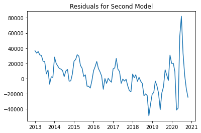

```python
fig, ax = plt.subplots()
ax.plot(log_sales_data.index, model2.resid)
plt.title("Residuals for Second Model")
plt.show()
```

#### When I look at the residuals, I can say that the mean is approximately zero.

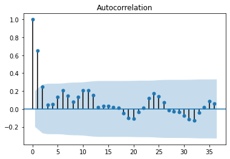

```python
plot_acf(model2.resid, lags=36)
plt.show()
```

#### As I compare the autocorrelation graph with two different models, it supports my assumption.

```python
last_month = [{"Date": "2020-12-01","sales":0,"trend":96,"month":12,"interest_rate":18.19}]
```

```python
last_month = pd.DataFrame(last_month)
last_month.set_index("Date")
last_month=last_month.dropna()[x.columns]
```

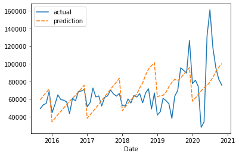

```python
preds_and_actual = pd.DataFrame()
preds_and_actual["actual"] = sales_data.sales
preds_and_actual["prediction"] =  (model2.predict(x))

sns.lineplot(data =preds_and_actual[32:180])
```

```python
model2.predict(last_month.values)
```

```
array([106297.84859563])
```

#### 106297 is my prediction for second hand home sales in Turkey for December 2020.

## Conclusion

#### In the second part I checked the data by looking the graphs and ACF's. Then I build different models. By analysing the models statistically I select the model that has the highest R-Squared(0.897).

#### In the last part I created the December-2020's dataframe and put the corresponding data into it. After that by using the best model I predict the December 2020 number of second hand home sales in Turkey. Also I plotted the graph of actual vs predicted data by using model.